# A2Sf Visitor Survey Analysis

Vicky Wang

# Understanding Ann Arbor Summer Festival Visitors, Post-, In- and Combined- Survey Results

## Post-Season Survey Data

1. Remove non-US auto-collected countries and manual zip code entries that are not 5 characters
2. Create a new column that determines initial Bot/Not Bot status by comparing auto-collected Country with manual-collected Zip Code

| Respondent ID | State | Country Code | Bot |
| --- | --- | --- | --- |
| 304885124 | Alabama | US | Not Bot |
| 304885234 | Arizona | US | Not Bot |
| 304882108 | California | US | Not Bot |
| 304882174 | California | US | Not Bot |
| 304883063 | California | US | Not Bot |
| 304883546 | California | US | Not Bot |

3. Checked for unusually short-duration surveys based on Start and End Date data. 0 Identified.

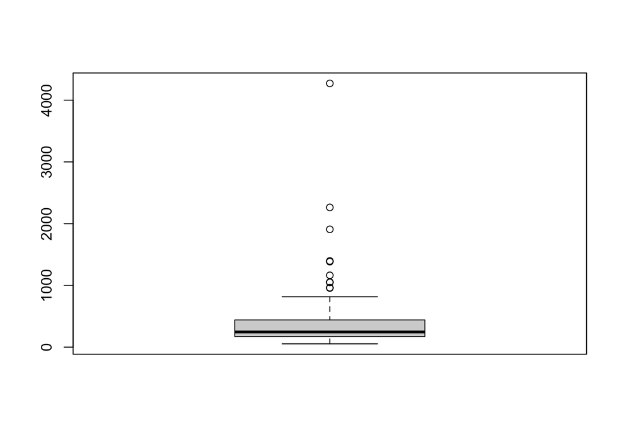

4. Created a new file after manually reading responses. Flagged previous “Not Bot”s as “Maybe”. Also filtered to leave only “Not Bot” remaining.

## **Where are People From?**

I collapsed all zip code counts of 1 into a single “Other” categorization.

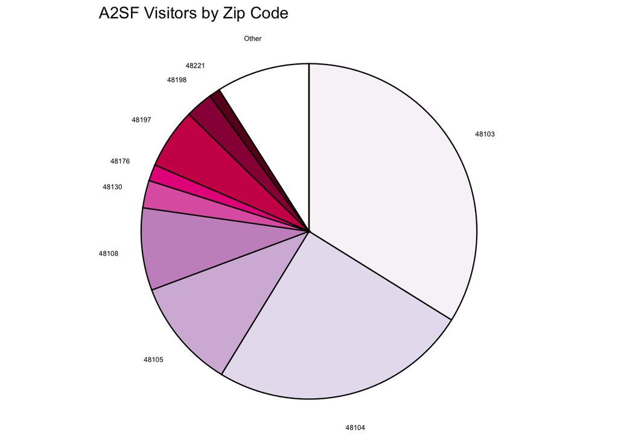

I had to manually geocode some components of latitude and longitude based on zip code because the geocode() function is not perfect. This allows me to map the zip code regions.

## Mapping Where A2SF Visitors are from

- Note that I found 2 additional zip codes that are invalid according to [Free Map Tools](https://www.freemaptools.com/convert-us-zip-code-to-lat-lng.htm).

[interactive chart not shown]